Rithvik Malladi, CMSC320, 117481419

# An Analysis of Base Stats in Pokemon Games

```python
#Required imports for this project.
import requests
import re
from bs4 import BeautifulSoup
import pandas as pd
import numpy as np
import seaborn as sns
import scipy.stats as ss
from sklearn import linear_model as lm
import sklearn.datasets as skd
import statsmodels.formula.api as smf
import statsmodels.api as sm
import matplotlib.pyplot as plt
from google.colab import drive
drive.mount('/content/drive')
#Setting Plot size for the entire project.
sns.set(rc = {'figure.figsize' : (16, 10)})
```

Required libraries for data analysis throughout this project. Some of these libraries may not be used.

## Introduction

The pokemon franchise is the largest grossing media franchise in the world, first and foremost being an extremely popular video game series. All pokemon games are role playing games(RPGs) that mostly revolve around the same mechanics of assuming the role of a player character in a respective pokemon region. Each game gives the play the option of catching creatures called pokemon that can fight in pokemon battles on behalf of the player character. Battles occur between pokemon with each party having a limit of 6 pokemon. Each pokemon has a typing out of 18 that determines weaknesses and strengths of moves that each pokemon can use to fight other pokemon. Each pokemon is limited to 4 moves and the goal of each of these games is to become the champion of the region the game takes place in by passing through a gauntlet of 8 pokemon gyms spread across the region and then taking another guantlet called the elite 4 before eventually fighting and hopefully defeating the pre-existing champion. These games have been made since 1996 and have amassed an enormous following of dedicated players, myself included.

However and underappreciated part of the community that is just now getting some more spotlight shone on it is competitve pokemon. Players have the ability to fight against friends and naturally serious competition arises from this. This idea has expandad into the competitve pokemon scene where thousands of players around the world engage in serious battle to compete in official and unoffical tournaments. Competitive pokemon tends to care about a lot more intricate features of pokemon and while this project won't talk about some of the more complicated aspects of competitve pokemon like EV spreads I do want to talk about pokemon base stats.

In this project I would like to examine base stats of pokemon and how these values trend across the history of the pokemon games.

### Explanation of Base Stats and Pokemon Generations

Before any data analysis begins, an understanding of what pokemon stats are and why they matter is necessary. Pokemon is a turn based RPG game series you fight and catch creatures called pokemon to fight battles for you. Each pokemon comes a typing that interacts with other pokemon's typings in positive and negative ways through attacks called moves. Pokemon also having certain effects called abilities that also influence how battles are fought. Finally and arguable most importantly pokemon have something called base stats which are numbers that influence how offensive, defensive, and fast pokemon are. There are 6 stats, those stats being **HP(Health Points), Attack, Defense, Special Attack, Special Defense, and Speed**. HP determines the overall health of a pokemon, Attack determines how much damage physical damaging moves do against opponents, Defense determines how much physical damage a pokemon takes, Special Attack and Special Defense work the same way as Attack and Defense but for special damaging moves, and Speed determines when a pokemon moves in a turn based battle. The baseline is these stats are extremely important in determining the viability of pokemon within the competitive scene so higher number and/or good distributions of these stats matter a lot. My prediction before any analysis begins is that on average stat totals increase across pokemon game release with newer pokemon on average having more stats than older pokmeon. I also want to extend this to each of the indivudal 6 stats a pokemon can have. Throughout the project I will classify pokemon by pokedex number and also by generation. Pokedex number is an identifier in pokemon that for the purposes of this project indicates when a pokemon was released. Whenever new pokemon are added to the list of all pokemon(pokedex) it becomes a new generation of pokemon. The original Pokemon Red and Blue games introduced 151 pokemon in 1996 and as such it was generation 1. When Pokemon Gold and Silver introduced 100 new pokemon in 1999 it became generation 2 and since then every time a signifigant amount of pokemon are added to the pokedex it becomes a new generation of pokemon.

## Data Gathering

The first step is to gather data on all of the pokemons base stats. Each time new pokemon are added to the list of pokemon it is reffered to as a new generation so the first thing to do is gather all pokemon stats and assign each pokemon to their respective generation generation.

```python
#Using the bulbepedia table of pokemon base stats for every pokemon up till the most current pokemon.
w = BeautifulSoup(requests.get('https://bulbapedia.bulbagarden.net/wiki/List_of_Pok%C3%A9mon_by_base_stats_(Generation_IX)').text)
all_pokemon = (w.findAll('table')[2]).prettify()
all_pokemon_df = pd.read_html(all_pokemon)[0]
all_pokemon_df.rename(columns = {'#' : 'Pokedex_Number', 'Pokémon' : 'Pokemon'}, inplace = True)
#This column was likely for the images for each pokemon on the website table, it is unecessary for this project.
all_pokemon_df.drop(['Unnamed: 1'], axis = 1, inplace = True)
all_pokemon_df.head()
```

|  | Pokedex_Number | Pokemon | HP | Attack | Defense | Sp. Attack | Sp. Defense | Speed | Total | Average |
| --- | --- | --- | --- | --- | --- | --- | --- | --- | --- | --- |
| 0 | 1 | Bulbasaur | 45 | 49 | 49 | 65 | 65 | 45 | 318 | 53.00 |
| 1 | 2 | Ivysaur | 60 | 62 | 63 | 80 | 80 | 60 | 405 | 67.50 |
| 2 | 3 | Venusaur | 80 | 82 | 83 | 100 | 100 | 80 | 525 | 87.50 |
| 3 | 3 | Venusaur (Mega Venusaur) | 80 | 100 | 123 | 122 | 120 | 80 | 625 | 104.17 |
| 4 | 4 | Charmander | 39 | 52 | 43 | 60 | 50 | 65 | 309 | 51.50 |

Using the beautiful soup library and pandas we can scrape the pokemon data and input the data into a pandas dataframe. The data is already formatted in a way that shows all of the base stats, the base stat total and even the average of the base stat total. There is no need to perform any more data formatting for now.

We also must make tables for each individual generation of pokemon and remove mega evolutions(a mechanic in generation 6 of pokemon, will be talked about more later on in the project) and speical pokemon like eternatus eternamx form that are unable to be used by players. Region specific forms like alolan forms and galarian forms will be given a new pokedex number to better mark them as belonging to the later generations as opposed to the newer ones.

```python
drops = []
for i, row in all_pokemon_df.iterrows():
  if('Mega ' in all_pokemon_df.at[i, 'Pokemon']):
    drops.append(i)
  if('Alolan' in all_pokemon_df.at[i, 'Pokemon']):
    all_pokemon_df.at[i, 'Pokedex_Number'] = 809
  if('Galarian' in all_pokemon_df.at[i, 'Pokemon']):
    all_pokemon_df.at[i, 'Pokedex_Number'] = 905
  if('Hisuian' in all_pokemon_df.at[i, 'Pokemon'] or 'Paldean' in all_pokemon_df.at[i, 'Pokemon']):
    all_pokemon_df.at[i, 'Pokedex_Number'] = 1019
all_pokemon_df.drop(index = 1043, inplace = True)
for i in drops:
  all_pokemon_df.drop(index = i, inplace = True)
all_pokemon_df.head()
```

|  | Pokedex_Number | Pokemon | HP | Attack | Defense | Sp. Attack | Sp. Defense | Speed | Total | Average |
| --- | --- | --- | --- | --- | --- | --- | --- | --- | --- | --- |
| 0 | 1 | Bulbasaur | 45 | 49 | 49 | 65 | 65 | 45 | 318 | 53.0 |
| 1 | 2 | Ivysaur | 60 | 62 | 63 | 80 | 80 | 60 | 405 | 67.5 |
| 2 | 3 | Venusaur | 80 | 82 | 83 | 100 | 100 | 80 | 525 | 87.5 |
| 4 | 4 | Charmander | 39 | 52 | 43 | 60 | 50 | 65 | 309 | 51.5 |
| 5 | 5 | Charmeleon | 58 | 64 | 58 | 80 | 65 | 80 | 405 | 67.5 |

While technically Hisuian pokemon were release in generation 8 and should be given the pokedex number 905, they were only elligable for competitve play in generation 9 so I am marking them as generation 9 pokemon as such.

## Exploratory Data Analysis

First let's plot all of the pokemon by Pokedex Number vs Base Stat Total.

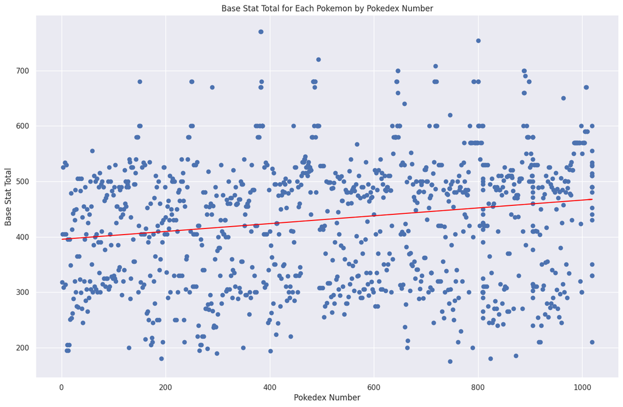

```python
plt.scatter(all_pokemon_df['Pokedex_Number'], all_pokemon_df['Total'])
plt.xlabel('Pokedex Number')
plt.ylabel('Base Stat Total')
plt.title('Base Stat Total for Each Pokemon by Pokedex Number')
m1, b1 = np.polyfit(all_pokemon_df['Pokedex_Number'], all_pokemon_df['Total'], 1)
plt.plot(all_pokemon_df['Pokedex_Number'], [(m1 * x) + b1 for x in all_pokemon_df['Pokedex_Number']], c = 'red')
plt.show()
```

Looking at this plot it is hard to tell if there is any noticable increase in base stats as newer pokemon are made. However with the help of a trendline is it apparent that the base stat totals are increasing over newer pokemon. Let's so how this looks when plotting the average base total per generation.

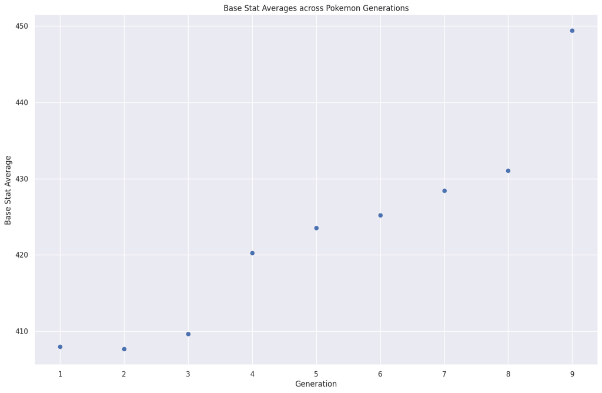

```python
#Finding the average base stat total per pokemon generation.
averages = [0, 0, 0, 0, 0, 0, 0, 0, 0]
total_num = [0, 0, 0, 0, 0, 0, 0, 0, 0]
for i, row in all_pokemon_df.iterrows():
  if(all_pokemon_df.at[i, 'Pokedex_Number'] <= 151):
    averages[0] += all_pokemon_df.at[i, 'Total']
    total_num[0] += 1
  if(all_pokemon_df.at[i, 'Pokedex_Number'] <= 251):
    averages[1] += all_pokemon_df.at[i, 'Total']
    total_num[1] += 1
  if(all_pokemon_df.at[i, 'Pokedex_Number'] <= 386):
    averages[2] += all_pokemon_df.at[i, 'Total']
    total_num[2] += 1
  if(all_pokemon_df.at[i, 'Pokedex_Number'] <= 493):
    averages[3] += all_pokemon_df.at[i, 'Total']
    total_num[3] += 1
  if(all_pokemon_df.at[i, 'Pokedex_Number'] <= 649):
    averages[4] += all_pokemon_df.at[i, 'Total']
    total_num[4] += 1
  if(all_pokemon_df.at[i, 'Pokedex_Number'] <= 721):
    averages[5] += all_pokemon_df.at[i, 'Total']
    total_num[5] += 1
  if(all_pokemon_df.at[i, 'Pokedex_Number'] <= 809):
    averages[6] += all_pokemon_df.at[i, 'Total']
    total_num[6] += 1
  if(all_pokemon_df.at[i, 'Pokedex_Number'] <= 905):
    averages[7] += all_pokemon_df.at[i, 'Total']
    total_num[7] += 1
  else:
    averages[8] += all_pokemon_df.at[i, 'Total']
    total_num[8] += 1
for x in range(0, 9):
  averages[x] = averages[x] / total_num[x]

#Plotting the average across generation.
plt.scatter(range(1, 10), averages)
plt.xlabel('Generation')
plt.ylabel('Base Stat Average')
plt.title('Base Stat Averages across Pokemon Generations')
plt.show()
```

We can see the average base stat total increase per generation, but sometimes certain pokemon need only certain stats and base stat total may not be an complete indication of increasing power level. We can also check averages for each individual stat and plot them as well.

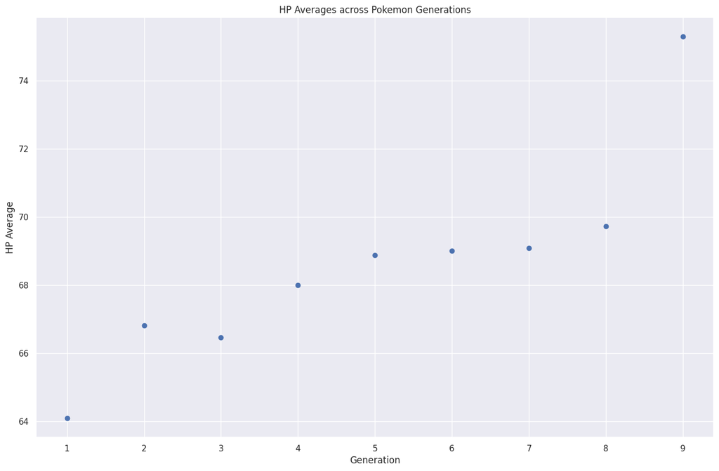

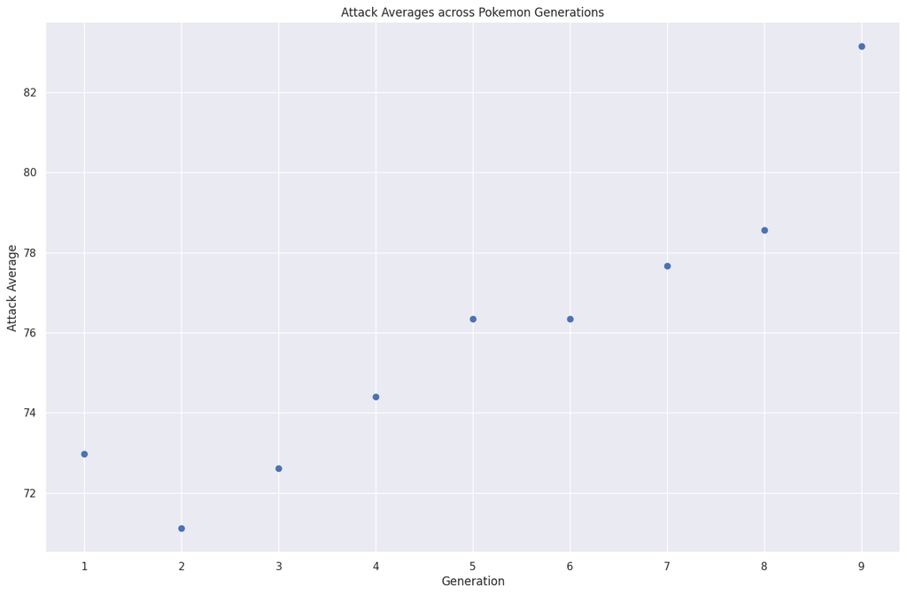

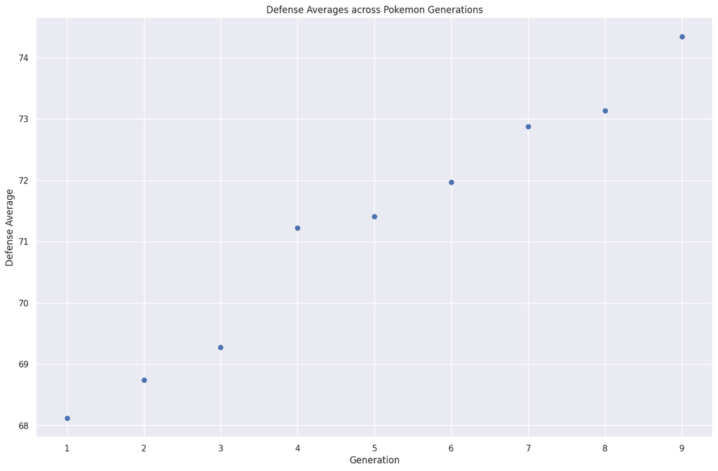

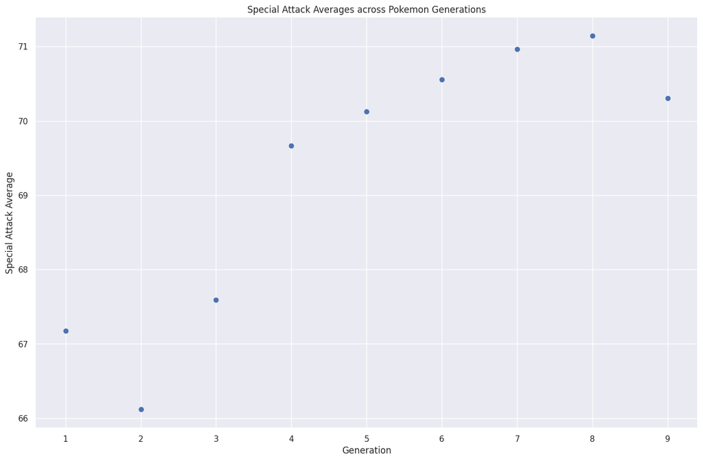

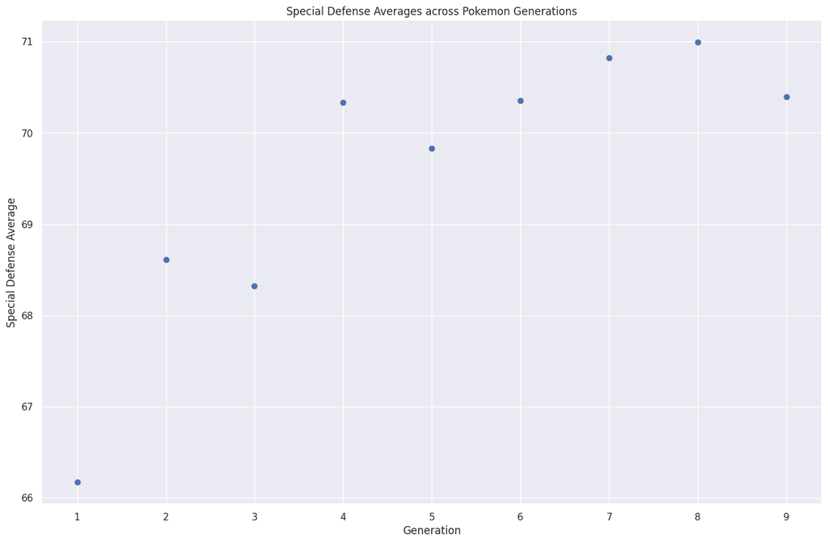

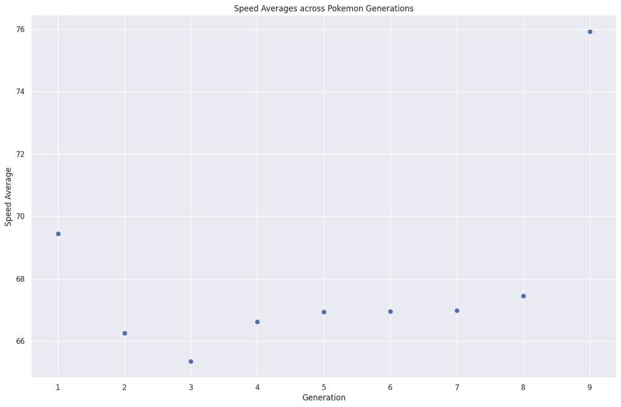

```python
#Plots for averages of HP, Attack, Defense, Sp. Attack, Sp. Defense, and Speed across each pokemon generation.
hp_averages = [0, 0, 0, 0, 0, 0, 0, 0, 0]
atk_averages = [0, 0, 0, 0, 0, 0, 0, 0, 0]
def_averages = [0, 0, 0, 0, 0, 0, 0, 0, 0]
spatk_averages = [0, 0, 0, 0, 0, 0, 0, 0, 0]
spdef_averages = [0, 0, 0, 0, 0, 0, 0, 0, 0]
spd_averages = [0, 0, 0, 0, 0, 0, 0, 0, 0]
for i, row in all_pokemon_df.iterrows():
  if(all_pokemon_df.at[i, 'Pokedex_Number'] <= 151):
    hp_averages[0] += all_pokemon_df.at[i, 'HP']
    atk_averages[0] += all_pokemon_df.at[i, 'Attack']
    def_averages[0] += all_pokemon_df.at[i, 'Defense']
    spatk_averages[0] += all_pokemon_df.at[i, 'Sp. Attack']
    spdef_averages[0] += all_pokemon_df.at[i, 'Sp. Defense']
    spd_averages[0] += all_pokemon_df.at[i, 'Speed']
  if(all_pokemon_df.at[i, 'Pokedex_Number'] <= 251):
    hp_averages[1] += all_pokemon_df.at[i, 'HP']
    atk_averages[1] += all_pokemon_df.at[i, 'Attack']
    def_averages[1] += all_pokemon_df.at[i, 'Defense']
    spatk_averages[1] += all_pokemon_df.at[i, 'Sp. Attack']
    spdef_averages[1] += all_pokemon_df.at[i, 'Sp. Defense']
    spd_averages[1] += all_pokemon_df.at[i, 'Speed']
  if(all_pokemon_df.at[i, 'Pokedex_Number'] <= 386):
    hp_averages[2] += all_pokemon_df.at[i, 'HP']
    atk_averages[2] += all_pokemon_df.at[i, 'Attack']
    def_averages[2] += all_pokemon_df.at[i, 'Defense']
    spatk_averages[2] += all_pokemon_df.at[i, 'Sp. Attack']
    spdef_averages[2] += all_pokemon_df.at[i, 'Sp. Defense']
    spd_averages[2] += all_pokemon_df.at[i, 'Speed']
  if(all_pokemon_df.at[i, 'Pokedex_Number'] <= 493):
    hp_averages[3] += all_pokemon_df.at[i, 'HP']
    atk_averages[3] += all_pokemon_df.at[i, 'Attack']
    def_averages[3] += all_pokemon_df.at[i, 'Defense']
    spatk_averages[3] += all_pokemon_df.at[i, 'Sp. Attack']
    spdef_averages[3] += all_pokemon_df.at[i, 'Sp. Defense']
    spd_averages[3] += all_pokemon_df.at[i, 'Speed']
  if(all_pokemon_df.at[i, 'Pokedex_Number'] <= 649):
    hp_averages[4] += all_pokemon_df.at[i, 'HP']
    atk_averages[4] += all_pokemon_df.at[i, 'Attack']
    def_averages[4] += all_pokemon_df.at[i, 'Defense']
    spatk_averages[4] += all_pokemon_df.at[i, 'Sp. Attack']
    spdef_averages[4] += all_pokemon_df.at[i, 'Sp. Defense']
    spd_averages[4] += all_pokemon_df.at[i, 'Speed']
  if(all_pokemon_df.at[i, 'Pokedex_Number'] <= 721):
    hp_averages[5] += all_pokemon_df.at[i, 'HP']
    atk_averages[5] += all_pokemon_df.at[i, 'Attack']
    def_averages[5] += all_pokemon_df.at[i, 'Defense']
    spatk_averages[5] += all_pokemon_df.at[i, 'Sp. Attack']
    spdef_averages[5] += all_pokemon_df.at[i, 'Sp. Defense']
    spd_averages[5] += all_pokemon_df.at[i, 'Speed']
  if(all_pokemon_df.at[i, 'Pokedex_Number'] <= 809):
    hp_averages[6] += all_pokemon_df.at[i, 'HP']
    atk_averages[6] += all_pokemon_df.at[i, 'Attack']
    def_averages[6] += all_pokemon_df.at[i, 'Defense']
    spatk_averages[6] += all_pokemon_df.at[i, 'Sp. Attack']
    spdef_averages[6] += all_pokemon_df.at[i, 'Sp. Defense']
    spd_averages[6] += all_pokemon_df.at[i, 'Speed']
  if(all_pokemon_df.at[i, 'Pokedex_Number'] <= 905):
    hp_averages[7] += all_pokemon_df.at[i, 'HP']
    atk_averages[7] += all_pokemon_df.at[i, 'Attack']
    def_averages[7] += all_pokemon_df.at[i, 'Defense']
    spatk_averages[7] += all_pokemon_df.at[i, 'Sp. Attack']
    spdef_averages[7] += all_pokemon_df.at[i, 'Sp. Defense']
    spd_averages[7] += all_pokemon_df.at[i, 'Speed']
  else:
    hp_averages[8] += all_pokemon_df.at[i, 'HP']
    atk_averages[8] += all_pokemon_df.at[i, 'Attack']
    def_averages[8] += all_pokemon_df.at[i, 'Defense']
    spatk_averages[8] += all_pokemon_df.at[i, 'Sp. Attack']
    spdef_averages[8] += all_pokemon_df.at[i, 'Sp. Defense']
    spd_averages[8] += all_pokemon_df.at[i, 'Speed']
for x in range(0, 9):
  hp_averages[x] = hp_averages[x] / total_num[x]
  atk_averages[x] = atk_averages[x] / total_num[x]
  def_averages[x] = def_averages[x] / total_num[x]
  spatk_averages[x] = spatk_averages[x] / total_num[x]
  spdef_averages[x] = spdef_averages[x] / total_num[x]
  spd_averages[x] = spd_averages[x] / total_num[x]

#Plotting the averages across generation.
plt.scatter(range(1, 10), hp_averages)
plt.xlabel('Generation')
plt.ylabel('HP Average')
plt.title('HP Averages across Pokemon Generations')
plt.show()
plt.scatter(range(1, 10), atk_averages)
plt.xlabel('Generation')
plt.ylabel('Attack Average')
plt.title('Attack Averages across Pokemon Generations')
plt.show()
plt.scatter(range(1, 10), def_averages)
plt.xlabel('Generation')
plt.ylabel('Defense Average')
plt.title('Defense Averages across Pokemon Generations')
plt.show()
plt.scatter(range(1, 10), spatk_averages)
plt.xlabel('Generation')
plt.ylabel('Special Attack Average')
plt.title('Special Attack Averages across Pokemon Generations')
plt.show()
plt.scatter(range(1, 10), spdef_averages)
plt.xlabel('Generation')
plt.ylabel('Special Defense Average')
plt.title('Special Defense Averages across Pokemon Generations')
plt.show()
plt.scatter(range(1, 10), spd_averages)
plt.xlabel('Generation')
plt.ylabel('Speed Average')
plt.title('Speed Averages across Pokemon Generations')
plt.show()
```

For all of these plots aside from speed it is apparent that the values are reletively increasing over generations of pokemon. Further analysis of these plots will be done in the Machine Learning section.

## Hypothesis Testing

In order to perform a hypothesis test on the data a Null Hypothesis(H0) and Alternative Hypothesis(H1) must be determined. For the purposes of this analysis H1 is that pokemon base stat totals are increasing over pokedex number while H0 is that they are not. We can use the statsmodels.formula.api library to perform a ordinary least squares analysis.

```python
#Statiscal Regression Using the statsmodels library.
model_total = smf.ols(formula = 'Total ~ Pokedex_Number', data = all_pokemon_df)
print(model_total.fit().summary())
```

```
                            OLS Regression Results
==============================================================================
Dep. Variable:                  Total   R-squared:                       0.033
Model:                            OLS   Adj. R-squared:                  0.032
Method:                 Least Squares   F-statistic:                     37.94
Date:                Sun, 20 Aug 2023   Prob (F-statistic):           1.01e-09
Time:                        05:12:16   Log-Likelihood:                -6904.7
No. Observations:                1122   AIC:                         1.381e+04
Df Residuals:                    1120   BIC:                         1.382e+04
Df Model:                           1
Covariance Type:            nonrobust
==================================================================================
                     coef    std err          t      P>|t|      [0.025      0.975]
----------------------------------------------------------------------------------
Intercept        395.3880      7.007     56.425      0.000     381.639     409.137
Pokedex_Number     0.0707      0.011      6.160      0.000       0.048       0.093
==============================================================================
Omnibus:                       26.276   Durbin-Watson:                   1.662
Prob(Omnibus):                  0.000   Jarque-Bera (JB):               14.158
Skew:                          -0.048   Prob(JB):                     0.000843
Kurtosis:                       2.458   Cond. No.                     1.26e+03
==============================================================================

Notes:
[1] Standard Errors assume that the covariance matrix of the errors is correctly specified.
[2] The condition number is large, 1.26e+03. This might indicate that there are
strong multicollinearity or other numerical problems.
```

After looking at the statistical summary after performing a regression analysis we can see that the p-value is less than 0.01 which means that there is statsical signifigance and the null hypothesis can be rejected. However the R-squared value is extremely low for the regression model which is very likely due to to the high variance in base stat totals as unevolved pokemon were also included in the data. Weaker pokemon can usually evolve into stronger pokemon. While the analysis could be performed on only fully evolved pokemon there are many cases where unevolved pokemon are also played in competitve matches due to certain strategies surrounding some unique mechanics they may have. Therefore to account for even the really weak pokemon I think is is right to include them in the analysis.

## Machine Learning

After fitting a linear regression for every pokemon I think it would be interesting to explore performing a gradient descent on the average base stat total per generation.

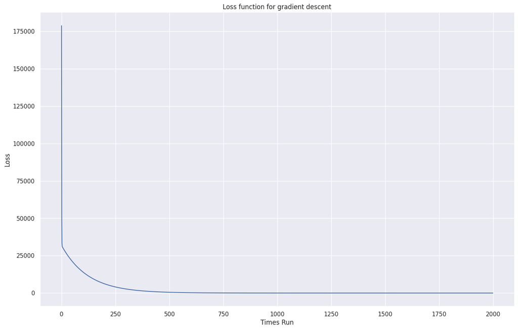

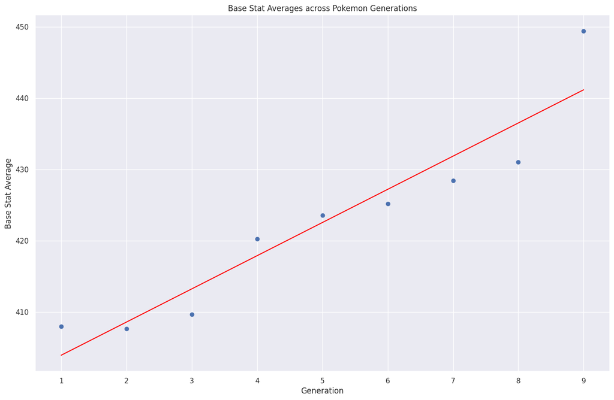

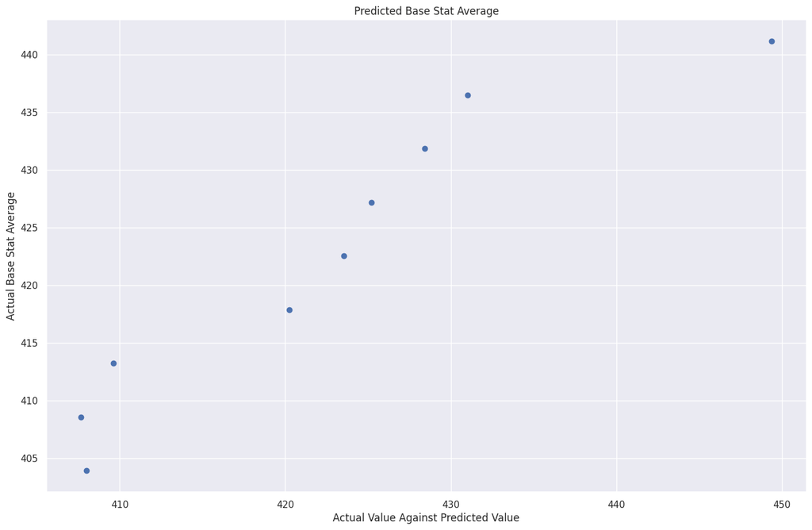

```python
def grad_descent(X, y, reps, alpha, n):
  m = 0
  b = 0
  f = []
  for x in range(0, 2000):
    predicted = (m * X) + b
    f.append(sum(((predicted - y) ** 2) / n))
    m -= alpha * ((2/n) * sum(X * (predicted - y)))
    b -= alpha * ((2/n) * sum(predicted - y))
  return m, b, f

t = 2000
m, b, f = grad_descent(np.array(range(1, 10)), np.array(averages), 2000, 0.01, float(len(averages)))

#Plot loss
plt.plot(range(t), f)
plt.xlabel('Times Run')
plt.ylabel('Loss')
plt.title('Loss function for gradient descent')
plt.show()
#Plot original scatter plot with regression line
plt.scatter(range(1, 10), averages)
plt.xlabel('Generation')
plt.ylabel('Base Stat Average')
plt.title('Base Stat Averages across Pokemon Generations')
plt.plot(range(1, 10), [(m * x) + b for x in range(1, 10)], c = 'red')
plt.show()
#Plot of actual value against predicted value
plt.xlabel('Actual Value Against Predicted Value')
plt.ylabel('Actual Base Stat Average')
plt.title('Predicted Base Stat Average')
plt.scatter(averages, [(m * x) + b for x in range(1, 10)])
plt.show()
```

We can use the same gradient descent for each of the 6 individual stats across pokemon generations.

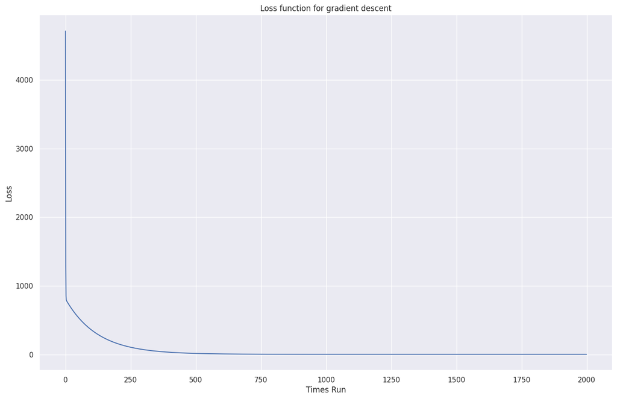

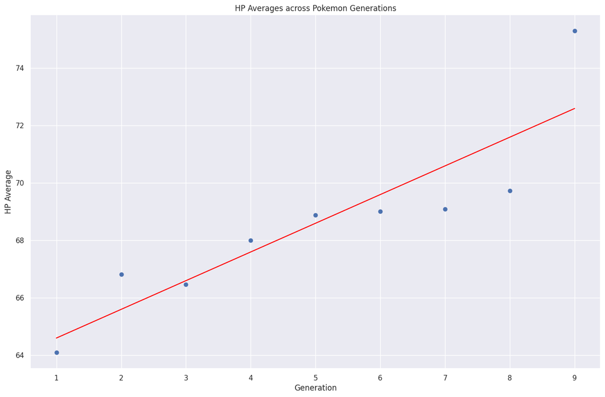

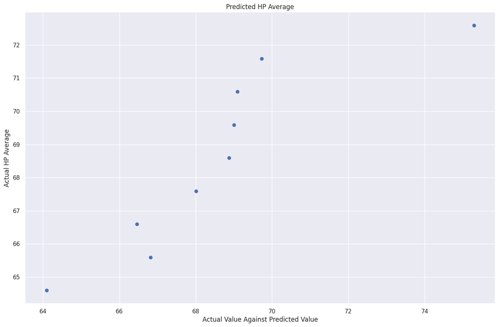

```python
#HP
m_hp, b_hp, f_hp = grad_descent(np.array(range(1, 10)), np.array(hp_averages), 2000, 0.01, float(len(hp_averages)))

#Plot loss
plt.plot(range(t), f_hp)
plt.xlabel('Times Run')
plt.ylabel('Loss')
plt.title('Loss function for gradient descent')
plt.show()
#Plot original scatter plot with regression line
plt.scatter(range(1, 10), hp_averages)
plt.xlabel('Generation')
plt.ylabel('HP Average')
plt.title('HP Averages across Pokemon Generations')
plt.plot(range(1, 10), [(m_hp * x) + b_hp for x in range(1, 10)], c = 'red')
plt.show()
#Plot of actual value against predicted value
plt.xlabel('Actual Value Against Predicted Value')
plt.ylabel('Actual HP Average')
plt.title('Predicted HP Average')
plt.scatter(hp_averages, [(m_hp * x) + b_hp for x in range(1, 10)])
plt.show()
```

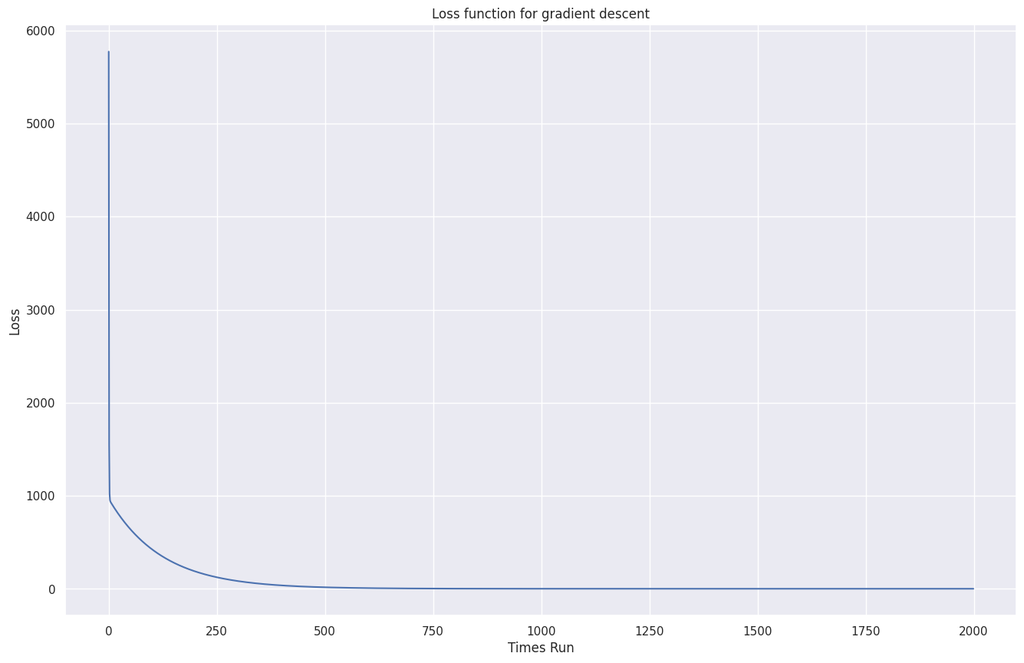

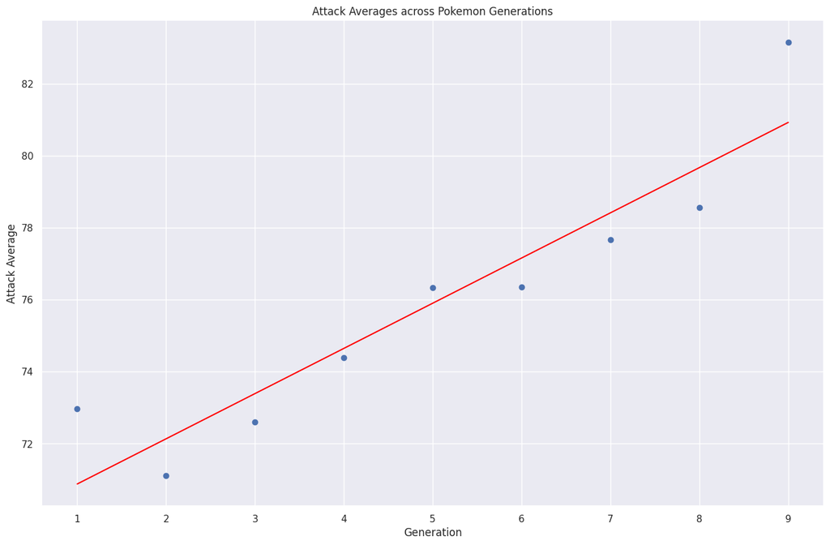

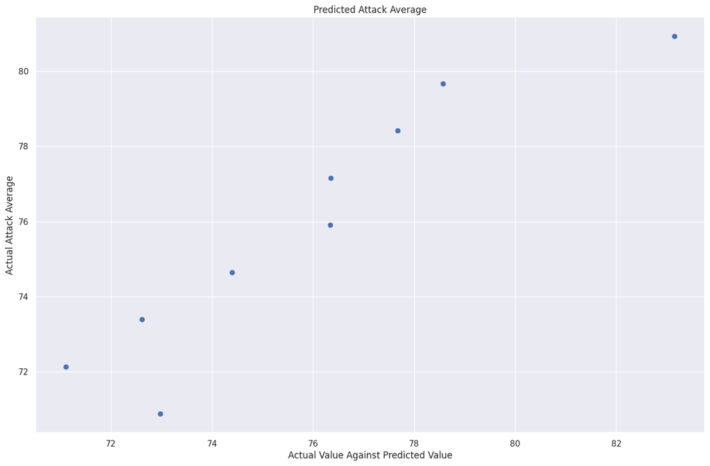

```python
#Attack
m_atk, b_atk, f_atk = grad_descent(np.array(range(1, 10)), np.array(atk_averages), 2000, 0.01, float(len(atk_averages)))

#Plot loss
plt.plot(range(t), f_atk)
plt.xlabel('Times Run')
plt.ylabel('Loss')
plt.title('Loss function for gradient descent')
plt.show()
#Plot original scatter plot with regression line
plt.scatter(range(1, 10), atk_averages)
plt.xlabel('Generation')
plt.ylabel('Attack Average')
plt.title('Attack Averages across Pokemon Generations')
plt.plot(range(1, 10), [(m_atk * x) + b_atk for x in range(1, 10)], c = 'red')
plt.show()
#Plot of actual value against predicted value
plt.xlabel('Actual Value Against Predicted Value')
plt.ylabel('Actual Attack Average')
plt.title('Predicted Attack Average')
plt.scatter(atk_averages, [(m_atk * x) + b_atk for x in range(1, 10)])
plt.show()
```

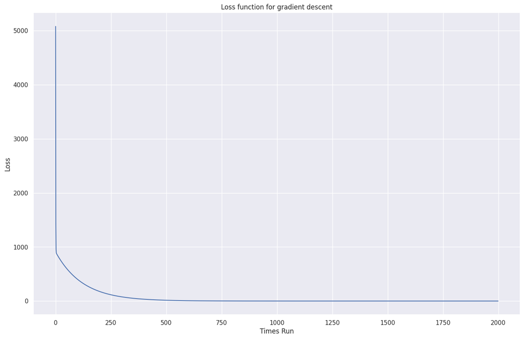

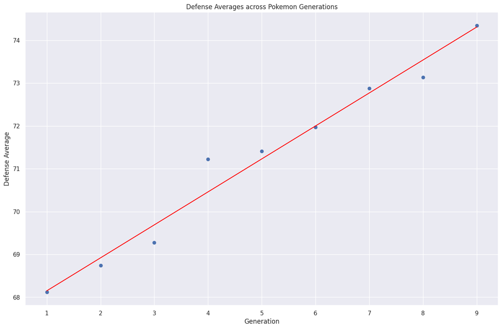

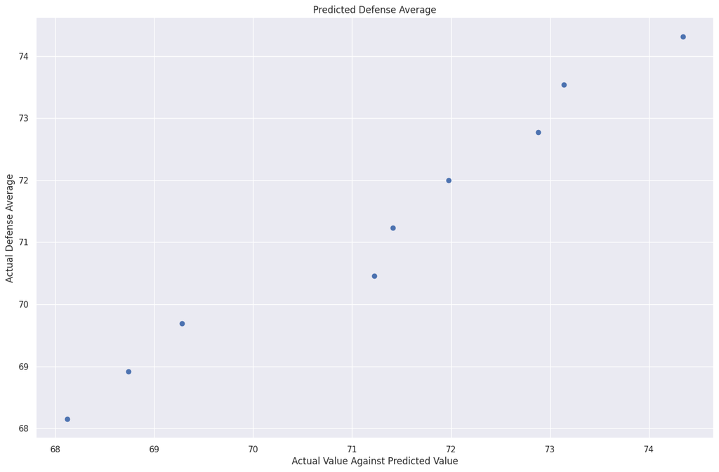

```python
#Defense
m_def, b_def, f_def = grad_descent(np.array(range(1, 10)), np.array(def_averages), 2000, 0.01, float(len(def_averages)))

#Plot loss
plt.plot(range(t), f_def)
plt.xlabel('Times Run')
plt.ylabel('Loss')
plt.title('Loss function for gradient descent')
plt.show()
#Plot original scatter plot with regression line
plt.scatter(range(1, 10), def_averages)
plt.xlabel('Generation')
plt.ylabel('Defense Average')
plt.title('Defense Averages across Pokemon Generations')
plt.plot(range(1, 10), [(m_def * x) + b_def for x in range(1, 10)], c = 'red')
plt.show()
#Plot of actual value against predicted value
plt.xlabel('Actual Value Against Predicted Value')
plt.ylabel('Actual Defense Average')
plt.title('Predicted Defense Average')
plt.scatter(def_averages, [(m_def * x) + b_def for x in range(1, 10)])
plt.show()
```

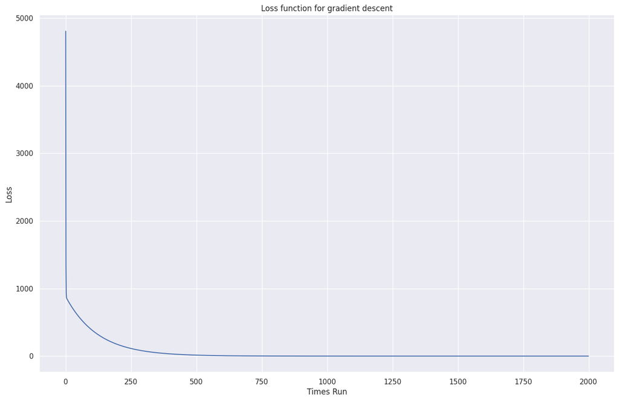

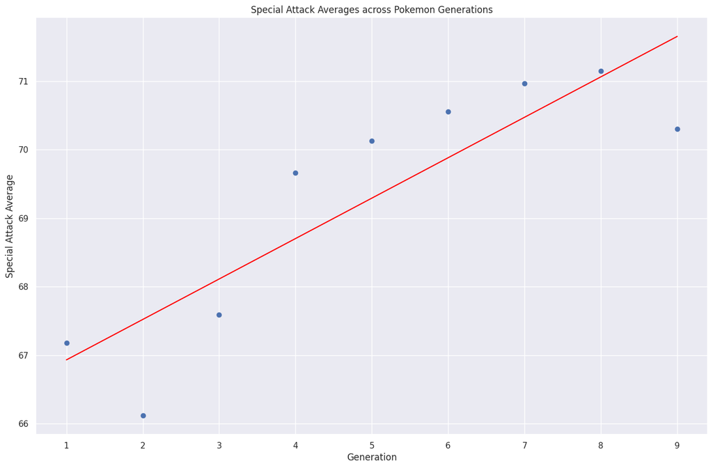

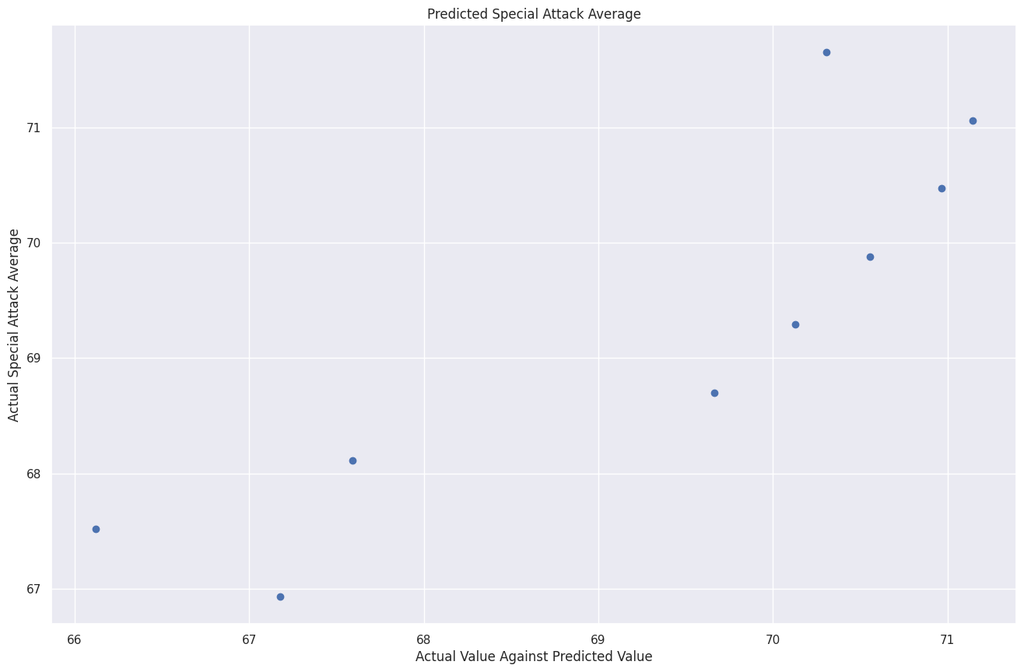

```python
#Special Attack
m_spatk, b_spatk, f_spatk = grad_descent(np.array(range(1, 10)), np.array(spatk_averages), 2000, 0.01, float(len(spatk_averages)))

#Plot loss
plt.plot(range(t), f_spatk)
plt.xlabel('Times Run')
plt.ylabel('Loss')
plt.title('Loss function for gradient descent')
plt.show()
#Plot original scatter plot with regression line
plt.scatter(range(1, 10), spatk_averages)
plt.xlabel('Generation')
plt.ylabel('Special Attack Average')
plt.title('Special Attack Averages across Pokemon Generations')
plt.plot(range(1, 10), [(m_spatk * x) + b_spatk for x in range(1, 10)], c = 'red')
plt.show()
#Plot of actual value against predicted value
plt.xlabel('Actual Value Against Predicted Value')
plt.ylabel('Actual Special Attack Average')
plt.title('Predicted Special Attack Average')
plt.scatter(spatk_averages, [(m_spatk * x) + b_spatk for x in range(1, 10)])
plt.show()
```

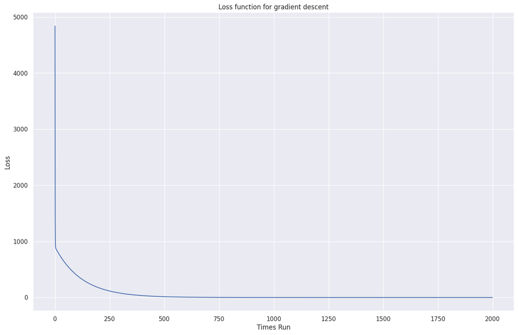

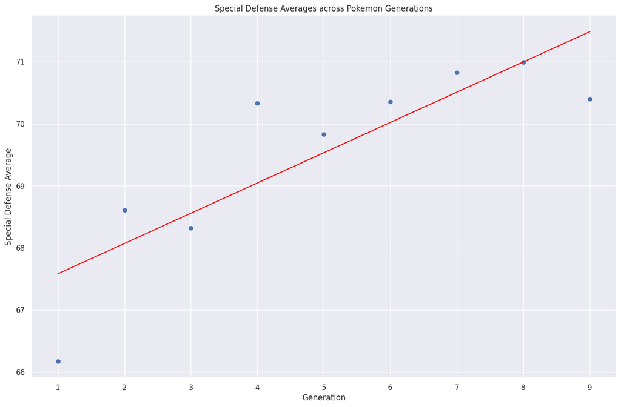

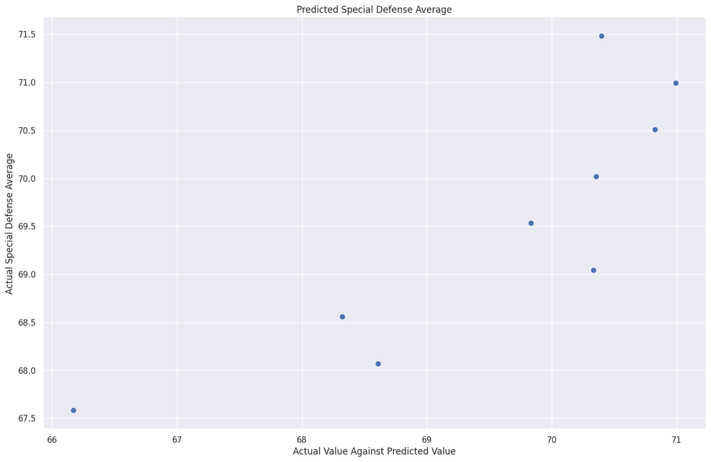

```python
#Special Defense
m_spdef, b_spdef, f_spdef = grad_descent(np.array(range(1, 10)), np.array(spdef_averages), 2000, 0.01, float(len(spdef_averages)))

#Plot loss
plt.plot(range(t), f_spdef)
plt.xlabel('Times Run')
plt.ylabel('Loss')
plt.title('Loss function for gradient descent')
plt.show()
#Plot original scatter plot with regression line
plt.scatter(range(1, 10), spdef_averages)
plt.xlabel('Generation')
plt.ylabel('Special Defense Average')
plt.title('Special Defense Averages across Pokemon Generations')
plt.plot(range(1, 10), [(m_spdef * x) + b_spdef for x in range(1, 10)], c = 'red')
plt.show()
#Plot of actual value against predicted value
plt.xlabel('Actual Value Against Predicted Value')
plt.ylabel('Actual Special Defense Average')
plt.title('Predicted Special Defense Average')
plt.scatter(spdef_averages, [(m_spdef * x) + b_spdef for x in range(1, 10)])
plt.show()
```

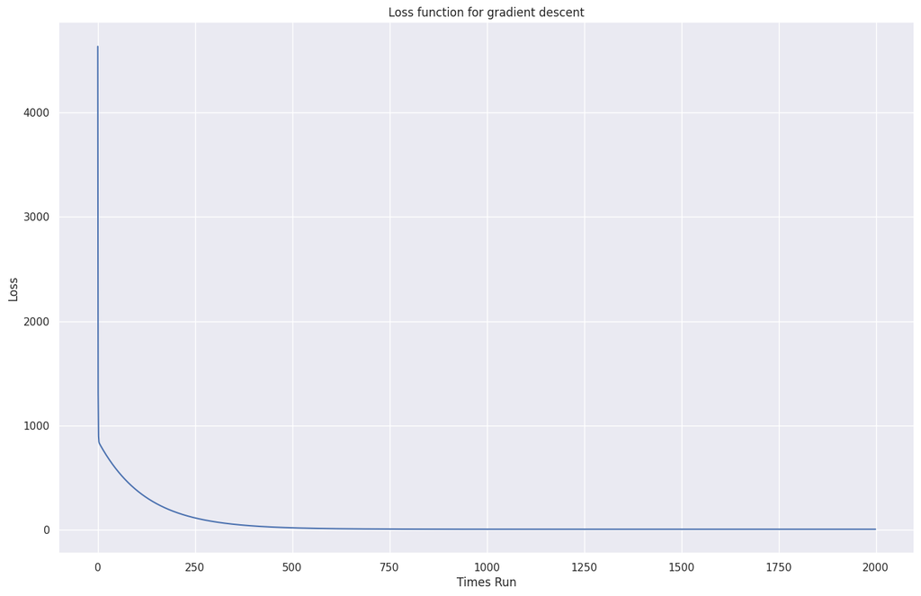

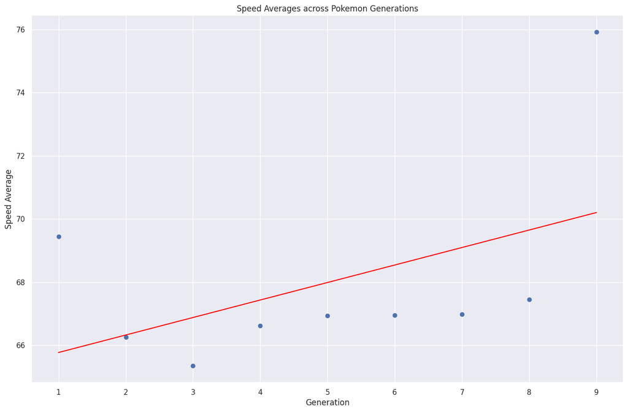

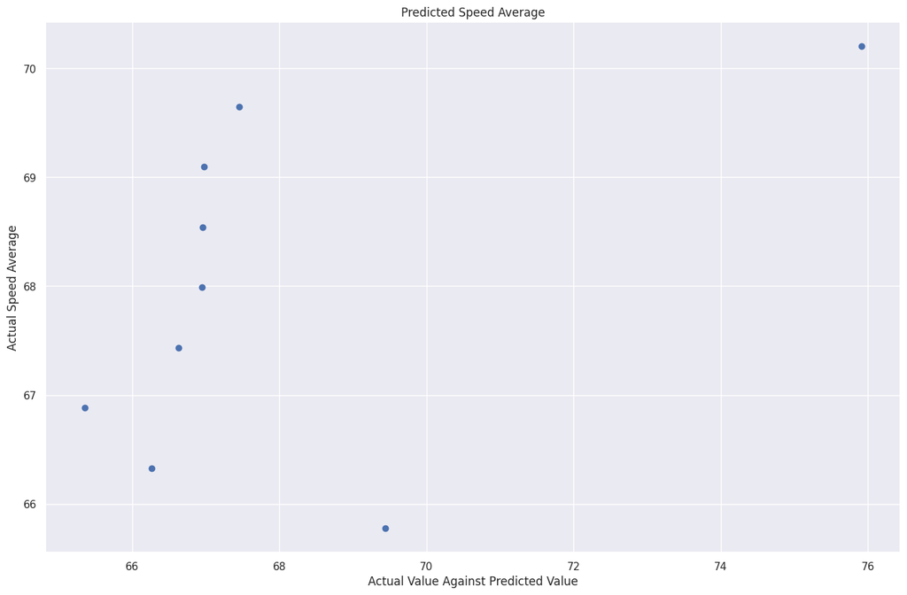

```python
#Speed
m_spd, b_spd, f_spd = grad_descent(np.array(range(1, 10)), np.array(spd_averages), 2000, 0.01, float(len(spd_averages)))

#Plot loss
plt.plot(range(t), f_spd)
plt.xlabel('Times Run')
plt.ylabel('Loss')
plt.title('Loss function for gradient descent')
plt.show()
#Plot original scatter plot with regression line
plt.scatter(range(1, 10), spd_averages)
plt.xlabel('Generation')
plt.ylabel('Speed Average')
plt.title('Speed Averages across Pokemon Generations')
plt.plot(range(1, 10), [(m_spd * x) + b_spd for x in range(1, 10)], c = 'red')
plt.show()
#Plot of actual value against predicted value
plt.xlabel('Actual Value Against Predicted Value')
plt.ylabel('Actual Speed Average')
plt.title('Predicted Speed Average')
plt.scatter(spd_averages, [(m_spd * x) + b_spd for x in range(1, 10)])
plt.show()
```

Every one of these analyses on base stat totals across generations shows an increasing relationship between stat in question and generation of pokemon. The only stat which doesn't quite show this relationship is speed while still increasing the best fit of regression doesn't necessarily seem to be linear.

```python
!pip install nbconvert
```

```python
!jupyter nbconvert --to html /content/FinalTutorial_RithvikMalladi.ipynb
```

[output not shown]

[output cut: 133 more lines]

[output not shown]